# Dolphin Data Analysis

Nicolas Restrepo

2/8/2021

## Introduction

```r
library(tidyverse)
```

```r
library(igraph)
library(brainGraph)
library(patchwork)
library(bayestestR)
```

Here, I am going to be approaching efficiency and diffusion in the dolphin networks using a more fine-tuned approach. This approach consists of taking into account the weights of the edges so that we do not actually have to backbone the networks, saving us the pitfall of discarding data. I will also use the removal data we have to explore how this affects the features of the static networks we have available.

## Efficiency

The measure of global efficiency is is the average of the inverse distances between all nodes in a network. When finding the shortest path between two nodes in an association matrix, however, there is room for error. The weight of the tie might be interpreted as distance and, thus, strong links would imply that agents are far apart. To enmend this I will use the inverse matrix to find the distances.

In this example I am going to work with wave 2 of the dolphin data.

```r
set.seed(76)
# Import the data
dolphin_edge_lists <- read_csv("Data/dolphin_edge_lists.csv")
```

```r
# Write function to return the graph from a wave
# Function to plot the networks
dolphin_edgelist <- function(w, t) {
  # Conditional statements for the waves
  if (w == 1) {
    c <- "T2008"
    title <- "Wave 1"
  } else {
    if(w ==2) {
      c <- "T2010"
      title <- "Wave 2"
    } else {
      if (w==3) {
        c <- "T2012"
        title <- "Wave 3"
      } else {
        if (w == 4) {
          c <- "T2014"
          title <- "Wave 4"
        } else {
          if (w == 5) {
            c <- "T2016"
            title <- "Wave 5"
          } else {
            c <- "T2018"
            title <- "Wave 6"
          }
        }
      }
    }
  }
  # Take the wave
  edgelist <- dolphin_edge_lists %>%
    select(1,2, c, 9) %>%
    filter(!is.na(.[,3]) & .[,3] >= t) %>%
    rename(weight = c,
           from = ID1,
           to = ID2)

  net <- graph_from_data_frame(edgelist, directed = FALSE)
  return(net)
}

# Get the second wave
dolphin_net_w2 <- dolphin_edgelist(w = 2,
                                   t = 0)
```

```
## Note: Using an external vector in selections is ambiguous.
## ℹ Use `all_of(c)` instead of `c` to silence this message.
## ℹ See <https://tidyselect.r-lib.org/reference/faq-external-vector.html>.
```

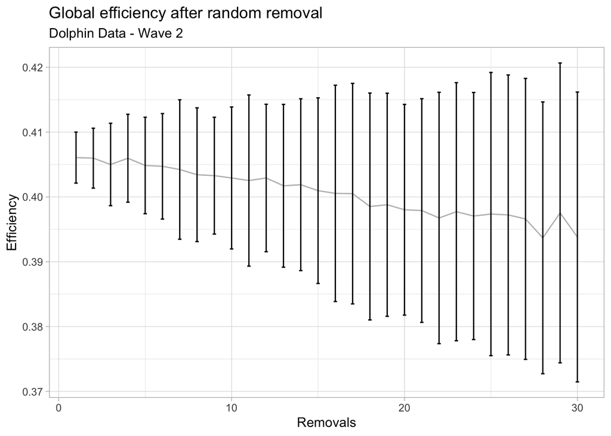

```r
# Turn it into an adjacency matrix
dolphin_mat_w2 <- as_adj(dolphin_net_w2,
                         attr = 'weight',
                         sparse = F)
# Get the inverse matrix
# Make a copy
dolphin_mat_inv <- dolphin_mat_w2

# Get the edges that are above 0
edges <- which(dolphin_mat_inv > 0)

# Now invert those
dolphin_mat_inv[edges] <- 1 - dolphin_mat_inv[edges]

# Populate the diagonal with 0s
diag(dolphin_mat_inv) <- 0

# Create the new graph
dolphin_net_inv <- graph_from_adjacency_matrix(dolphin_mat_inv,
                                   weighted = T,
                                   mode = 'undirected')

# Our function for efficiency after removal
efficiency_after_random_removal <- function(g, reps, num_removals) {
  # placeholder
  efficiencies <- rep(NA, reps)

  for (i in 1:reps) {
    rmv <- sample(1:vcount(g), num_removals)
    ng <- delete.vertices(g,rmv)
    D <- distances(ng,
               weights = E(ng)$weight)
    D <- D + 1
    diag(D) <- 0
    Nv <- nrow(D)
    Dinv <- 1/D
    eff <- colSums(Dinv * is.finite(Dinv), na.rm = T)/(Nv - 1)
    geff <- sum(eff)/length(eff)
    efficiencies[i] <- geff
  }
  avg_eff <- mean(efficiencies)
  sd_eff <- sd(efficiencies)
  upper <- avg_eff + 1.96*sd_eff
  lower <- avg_eff - 1.96*sd_eff
  return(c(avg_eff = avg_eff,
           upper = upper,
           lower = lower,
           removals = num_removals))
}

# Dataset for eff at different levels of removal
dolphin_rr_df <- map_df(c(1:30),
                    efficiency_after_random_removal,
                        g=dolphin_net_inv,
                        reps = 100)

dolphin_rr_df %>%
  ggplot(aes(x = removals, y = avg_eff)) +
  geom_line(color = "gray") +
  geom_errorbar(aes(ymin = lower, ymax = upper), width = 0.2) +
  theme_light() +
  labs(title = "Global efficiency after random removal",
       subtitle = "Dolphin Data - Wave 2",
       x = "Removals",
       y = "Efficiency")
```

We notice the same pattern as we did in the elephant data: the variances increases dramatically with random removal but we cannot speak of a clear central tendency.

Let’s look at centrality-based removal. The difference here is that I am going to consider efficiency using the reverse-coded graph but I will assess centrality using our original network.

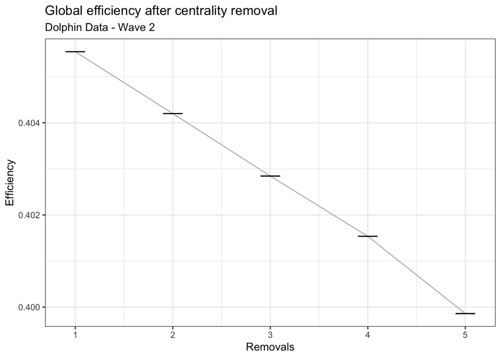

```r
# Write a function for removal of central nodes
efficiency_after_centrality_removal <- function(g, reps, num_removals, cent_scores) {
  # placeholder
  efficiencies <- rep(NA, reps)

  for (i in 1:reps) {
    centrality <- cent_scores
    centrality <- sort(centrality, decreasing = T)
    central_nodes <- names(centrality)
    ng <- delete.vertices(g,central_nodes[1:num_removals])
    D <- distances(ng,
               weights = E(ng)$weight)
    D <- D + 1
    diag(D) <- 0
    Nv <- nrow(D)
    Dinv <- 1/D
    eff <- colSums(Dinv * is.finite(Dinv), na.rm = T)/(Nv - 1)
    geff <- sum(eff)/length(eff)
    efficiencies[i] <- geff
  }
  avg_eff <- mean(efficiencies)
  sd_eff <- sd(efficiencies)
  upper <- avg_eff + 1.96*sd_eff
  lower <- avg_eff - 1.96*sd_eff
  return(c(avg_eff = avg_eff,
           upper = upper,
           lower = lower,
           removals = num_removals))
}

# Dataset for eff at different levels of removal
dolphin_rr_df <- map_df(c(1:5),
                    efficiency_after_centrality_removal,
                        g=dolphin_net_inv,
                        reps = 100,
                    cent_scores = eigen_centrality(dolphin_net_w2)$vector)

dolphin_rr_df %>%
  ggplot(aes(x = removals, y = avg_eff)) +
  geom_line(color = "gray") +
  geom_errorbar(aes(ymin = lower, ymax = upper), width = 0.2) +
  theme_bw() +
  labs(title = "Global efficiency after centrality removal",
       subtitle = "Dolphin Data - Wave 2",
       x = "Removals",
       y = "Efficiency")
```

There is an almost linear decline, much clearer than in our elephant data.

## Weighted Diffusion

I want to simulate diffusion but in a way that can incorporate what we know about the edge weights. In the current simulation, I let each edge add a probability of transmission equal to its weight (i.e. $\frac{weight}{1}$. The sum of these fractions for all edges that an agent j has represents its probability of acquiring the behavior in a given turn.

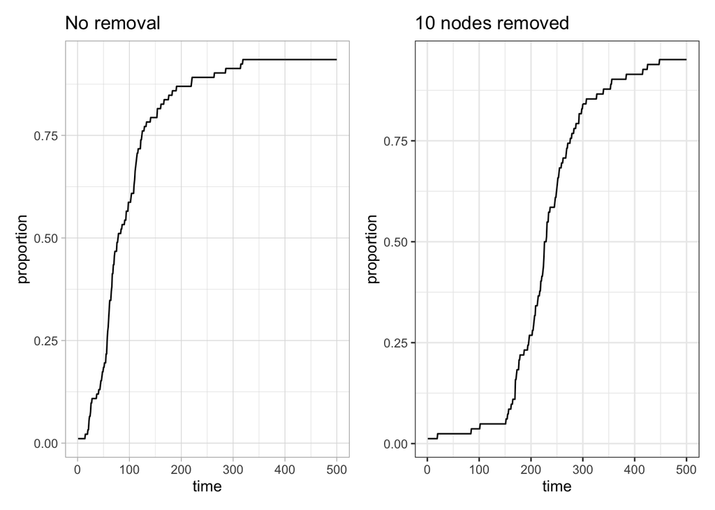

```r
set.seed(76)
# Contagion model from Acerbi et al (2020)
info_contagion <- function(net, rewire, e = 1, r_max, sim = 1){

  # Rewire network if random is set to TRUE
  if(rewire){
    net <- rewire(graph = net, with = keeping_degseq(loops = F, niter = 10^3))
  }

  # Get adjacency matrix from network
  adjm <- get.adjacency(net,
                        sparse = F,
                        attr = "weight")

  # Turn adjacency matrix into boolean (TRUE / FALSE) - if you dont want weights
  # adjm_bool <- adjm > 0

  # Set number of individuals based adjacency matrix
  N <- vcount(net)

  # Create a vector indicating possession of info and set one entry to TRUE
  info <- rep(FALSE, N)
  info[sample(x = N, size = 1)] <- TRUE

  # Create a reporting variable
  proportion <- rep(0, r_max)

  # Rounds
  for(r in 1:r_max){
    # In random sequence go through all individuals without info
    for(i in sample(N)){
      # Select i's neighbourhood
      nei <- adjm[i,] > 0
      # If you dont want to include weights, quote above, unquote below
      #nei <- adjm_bool[i,]
      # Proceed if there is at least one neighbour
      if(sum(nei) > 0){
        # Simple contagion for e = 1 and complex contagion for e = 2
        if(runif(n = 1, min = 0, max = 1) <= (sum(adjm[i,][info])/length(nei))^e){
          info[i] <- TRUE
        }
      }
    }
    # Record proportion of the population with info
    proportion[r] <- sum(info) / N
    # Increment the round counter
    r <- r + 1
  }
  # Return a tibble with simulation results
  return(tibble(time = 1:r_max,
                proportion = proportion,
                time_to_max = which(proportion == max(proportion))[1],
                e = e,
                network = ifelse(test = rewire, yes = "random", no = "model output"),
                sim = sim))
}

# Contagion with no removal
d_sim_nr <- info_contagion(dolphin_net_w2,
                           rewire = F,
                           e = 1,
                           r_max = 500)

p1 <- d_sim_nr %>%
  ggplot(aes(x = time, y = proportion)) +
  geom_line() +
  theme_light() +
  labs(title = "No removal")

# Now some random removal
rmv <- sample(1:vcount(dolphin_net_w2), 10)
ng <- delete.vertices(dolphin_net_w2, rmv)


# Contagion with random removal
d_sim_r <- info_contagion(ng,
                           rewire = F,
                           e = 1,
                           r_max = 500)

p2 <- d_sim_r %>%
  ggplot(aes(x = time, y = proportion)) +
  geom_line() +
  theme_bw() +
  labs(title = "10 nodes removed")

p1 + p2
```

We see that the spread is slower when nodes have been removed. Let’s repeat this process for several times and see how both diffusion trajectories compare on average.

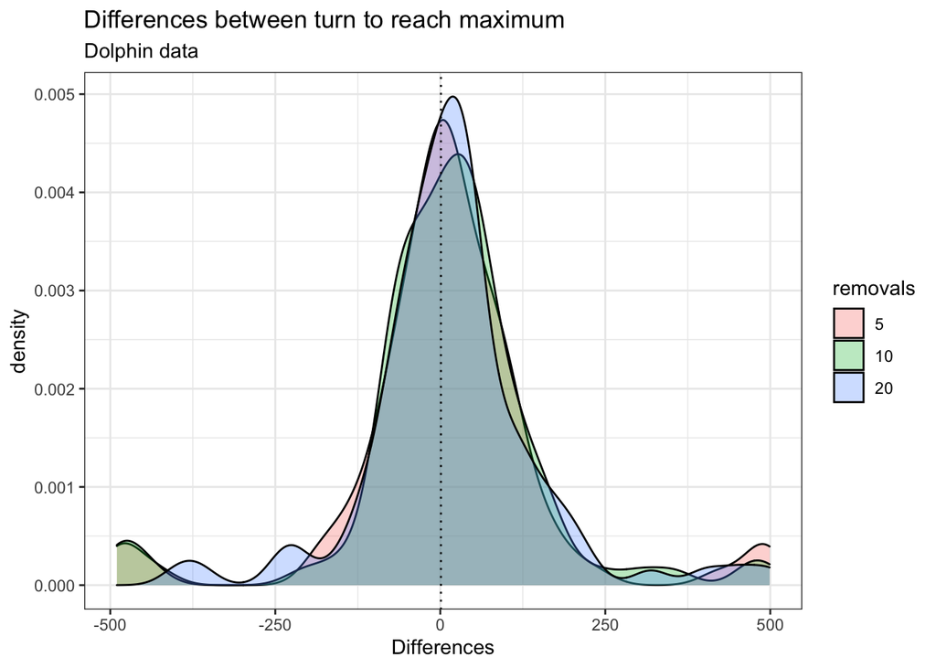

```r
turn_reached_max <- function(ev, g, reps, turns, num_removals) {
  # Place holder
  values <- rep(NA, reps)

  for (i in 1:reps) {
    sim <- info_contagion(g,
                          rewire = F,
                          e = ev,
                          r_max = turns)
    ttm <- sim$time_to_max[1]

    # Now some random removal
    rmv <- sample(1:vcount(g), num_removals)
    ng <- delete.vertices(g, rmv)
    sim_r <- info_contagion(ng,
                            rewire = F,
                            e = ev,
                            r_max = turns)
    ttmr <- sim_r$time_to_max[1]

    values[i] <- ttm-ttmr
  }
  return(values)
}

diffs_10_rems <- turn_reached_max(ev = 1,
                 g = dolphin_net_w2,
                 reps = 100,
                 turns = 500,
                 num_removals = 10)
diffs_20_rems <- turn_reached_max(ev = 1,
                 g = dolphin_net_w2,
                 reps = 100,
                 turns = 500,
                 num_removals = 20)
diffs_5_rems <- turn_reached_max(ev = 1,
                 g = dolphin_net_w2,
                 reps = 100,
                 turns = 500,
                 num_removals = 5)

ttm_dolphin <- tibble(ratios = c(diffs_5_rems, diffs_10_rems, diffs_20_rems),
                        removals = rep(c(5, 10, 20), each = 100)) %>%
  mutate(removals = as.factor(removals))

ttm_dolphin %>%
  ggplot(aes(x = ratios, fill = removals)) +
  geom_density(alpha = 0.3) +
  geom_vline(xintercept = 1, linetype = 3) +
  theme_bw() +
  labs(title = "Differences between turn to reach maximum",
       subtitle = "Dolphin data",
       x = "Differences")
```

As in previous analyses, we notice there is not a clear pattern here. Just from these distributions, it is difficult to discern whether random removal leads to quicker or more sluggish trajectories of transmission.

Let us examine these differences when we conduct centrality-based removal.

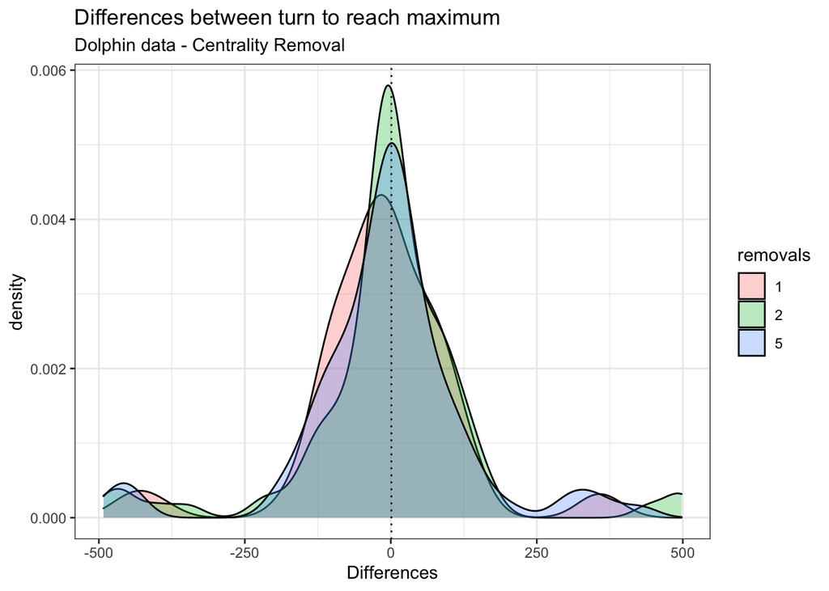

```r
turn_reached_max_centrality <- function(ev, g, reps, turns, num_removals) {
  # Place holder
  values <- rep(NA, reps)

  for (i in 1:reps) {
    sim <- info_contagion(g,
                          rewire = F,
                          e = ev,
                          r_max = turns)
    ttm <- sim$time_to_max[1]

    # Now some centrality removal
    centrality <- eigen_centrality(g)$vector
    centrality <- sort(centrality, decreasing = T)
    central_nodes <- names(centrality)
    ng <- delete.vertices(g,central_nodes[1:num_removals])
    sim_r <- info_contagion(ng,
                            rewire = F,
                            e = ev,
                            r_max = turns)
    ttmr <- sim_r$time_to_max[1]

    values[i] <- ttm-ttmr
  }
  return(values)
}

diffs_5_rems <- turn_reached_max_centrality(ev = 1,
                 g = dolphin_net_w2,
                 reps = 100,
                 turns = 500,
                 num_removals = 5)
diffs_2_rems <- turn_reached_max_centrality(ev = 1,
                 g = dolphin_net_w2,
                 reps = 100,
                 turns = 500,
                 num_removals = 2)
diffs_1_rems <- turn_reached_max_centrality(ev = 1,
                 g = dolphin_net_w2,
                 reps = 100,
                 turns = 500,
                 num_removals = 1)

aucs_dolphins <- tibble(ratios = c(diffs_5_rems, diffs_1_rems, diffs_2_rems),
                        removals = rep(c(5, 1, 2), each = 100)) %>%
  mutate(removals = as.factor(removals))

aucs_dolphins %>%
  ggplot(aes(x = ratios, fill = removals)) +
  geom_density(alpha = 0.3) +
  geom_vline(xintercept = 1, linetype = 3) +
  theme_bw() +
  labs(title = "Differences between turn to reach maximum",
       subtitle = "Dolphin data - Centrality Removal",
       x = "Differences")
```

## Data-Based Removal

We have good information about what kind of nodes we leave from one wave to another in out dolphin data. Let’s see how efficiency and diffusion patterns are affected then we remove the nodes that actually left the network. I will do this for all waves except for the last one, where we have no information about the further removals.

I will document each step so what I am doing is clear. I will begin with wave 1.

### Wave 1

```r
# Import the ID list data
# Contains removal information

id_list <- read_csv("Data/ID_list.csv")
head(id_list)
```

```
## # A tibble: 6 x 12
##   Dolphin.ID T2008 T2010 T2012 T2014 T2016 T2018 Birth.Date Weaning.Date
##   <chr>      <dbl> <dbl> <dbl> <dbl> <dbl> <dbl> <date>     <date>
## 1 ID0001        NA    NA     4    14     8     6 2009-11-01 2013-06-08
## 2 ID0002        12    13    21    18    13    15 2004-01-01 2007-05-30
## 3 ID0003        12    19     5    NA    NA    NA 1972-11-01 NA
## 4 ID0004        16    23    28    36    22    15 1975-11-01 NA
## 5 ID0005        11    21    22    16    10     7 1970-11-01 NA
## 6 ID0006        NA    NA    NA    32    21    28 2011-11-20 2015-06-03
## # … with 3 more variables: Last.Sighting.Date <date>, Death.Date <date>,
## #   Sex <chr>
```

We have useful data about what nodes appear in each wave. Now, let’s see how many that were in wave 1 did not show up in wave 2.

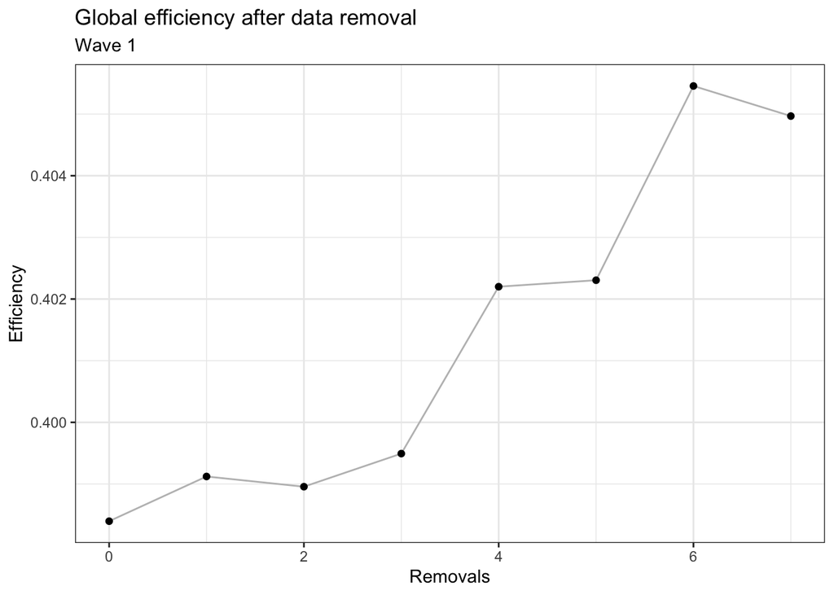

```r
# Get a vector of the nodes that were removed
removed_nodes <- id_list %>%
  select(1:3) %>%
  filter(!is.na(T2008)&is.na(T2010)) %>%
  pull(Dolphin.ID)

# Write function to get efficiency of inverse matrix
inverse_efficiency <- function(g) {
# Turn it into an adjacency matrix
net_mat <- as_adj(g,
                  attr = 'weight',
                  sparse = F)
# Get the inverse matrix
mat_inv <- net_mat
edges <- which(mat_inv > 0)
mat_inv[edges] <- 1 - mat_inv[edges]
# Populate the diagonal with 0s
diag(mat_inv) <- 0

# Create the new graph
net_inv <- graph_from_adjacency_matrix(mat_inv,
                                       weighted = T,
                                       mode = 'undirected')
    D <- distances(net_inv,
               weights = E(net_inv)$weight)
    D <- D + 1
    diag(D) <- 0
    Nv <- nrow(D)
    Dinv <- 1/D
    eff <- colSums(Dinv * is.finite(Dinv), na.rm = T)/(Nv - 1)
    geff <- sum(eff)/length(eff)

    return(geff)
}

# Get the graph for wave 1
dolphin_w1 <- dolphin_edgelist(w = 1,
                               t = 0)

# Record different efficiencies after systematic removal

effs_data_removal_w1 <- matrix(NA, nrow = length(removed_nodes)+1, ncol = 2 )

for (i in 0:7) {
  if (i == 0) {
    eff <- inverse_efficiency(dolphin_w1)
    effs_data_removal_w1[i+1,] <- c(i, eff)
  } else {
    ng <- delete.vertices(dolphin_w1, removed_nodes[1:i])
    eff <- inverse_efficiency(ng)
    effs_data_removal_w1[i+1,] <- c(i, eff)
  }
}

p1 <- data.frame(effs_data_removal_w1) %>%
  rename(removals = X1,
         efficiency = X2) %>%
  ggplot(aes(x = removals, y = efficiency)) +
  geom_line(color = "gray") +
  geom_point() +
  theme_bw() +
  labs(title = "Global efficiency after data removal",
       subtitle = "Wave 1",
       x = "Removals",
       y = "Efficiency")
p1
```

Okay, this plot shows that if we remove the nodes that actually left the network from wave 1 to 2, the global efficiency slightly improves. The improvement, however, is very small.

I am going to write a function to do this iteratively for each wave.

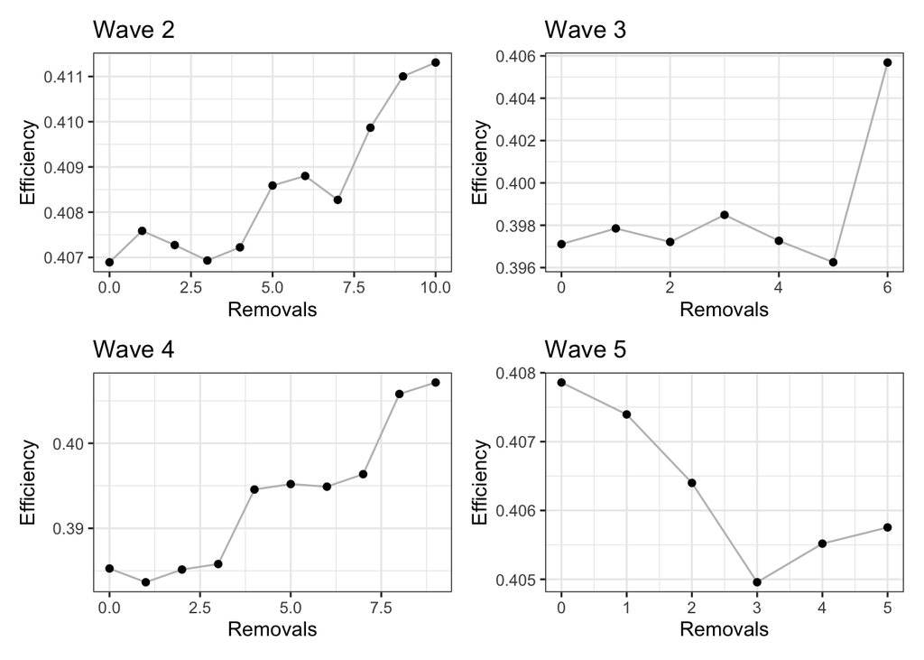

```r
efficiency_data_removal <- function(wave) {

# Get the network we need
  dnet <- dolphin_edgelist(w = wave,
                           t = 0)
# Get a vector of the nodes that were removed
removed_nodes <- id_list %>%
  select(1,wave+1,wave+2) %>%
  filter(!is.na(.[,2])&is.na(.[,3])) %>%
  pull(Dolphin.ID)

# Record different efficiencies after systematic removal

effs_data_removal <- matrix(NA, nrow = length(removed_nodes)+1, ncol = 2 )

for (i in 0:length(removed_nodes)) {
  if (i == 0) {
    eff <- inverse_efficiency(dnet)
    effs_data_removal[i+1,] <- c(i, eff)
  } else {
    ng <- delete.vertices(dnet, removed_nodes[1:i])
    eff <- inverse_efficiency(ng)
    effs_data_removal[i+1,] <- c(i, eff)
  }
}

return(data.frame(effs_data_removal) %>%
         rename(removals = X1,
         efficiency = X2))

}

p2 <- efficiency_data_removal(wave = 2) %>%
  ggplot(aes(x = removals, y = efficiency)) +
  geom_line(color = "gray") +
  geom_point() +
  theme_bw() +
  labs(title = "Wave 2",
       x = "Removals",
       y = "Efficiency")
p3 <- efficiency_data_removal(wave = 3) %>%
  ggplot(aes(x = removals, y = efficiency)) +
  geom_line(color = "gray") +
  geom_point() +
  theme_bw() +
  labs(title = "Wave 3",
       x = "Removals",
       y = "Efficiency")
p4 <- efficiency_data_removal(wave = 4) %>%
  ggplot(aes(x = removals, y = efficiency)) +
  geom_line(color = "gray") +
  geom_point() +
  theme_bw() +
  labs(title = "Wave 4",
       x = "Removals",
       y = "Efficiency")
p5 <- efficiency_data_removal(wave = 5) %>%
  ggplot(aes(x = removals, y = efficiency)) +
  geom_line(color = "gray") +
  geom_point() +
  theme_bw() +
  labs(title = "Wave 5",
       x = "Removals",
       y = "Efficiency")

(p2 | p3) / (p4 | p5)
```

I think the issue we need to explore is what sort of edge removal results in less efficient networks. We might start from the result and work backwards to see if we can infer any patterns.

## Exploration of Removals

In this section, I am going to do that. I am going to take one network and remove five nodes, in such a way that I can lower the efficiency as much as possible. Then, I am going to see if there are any shared features amid the nodes that get removed.

First let me write a function, that when given a graph, will tell me how removing each vertex will affect the graph’s efficiency.

```r
decrease_efficiency <- function(g) {
# Get the original efficiency
og_geff <- inverse_efficiency(g)
# A matrix to store the data
removal_df <- matrix(NA, ncol = 5, nrow = length(V(g)))

for (i in 1:length(V(g))) {
  vert <- V(g)[i]
  deg <- degree(g)[vert]
  cent <- eigen_centrality(g, weights = E(g)$weight)$vector[vert]
  net_mat <- as_adj(g, attr = 'weight', sparse = F)
  sum_weigths <- sum(net_mat[vert,])
  ng <- delete.vertices(g, vert)
  eff <- inverse_efficiency(ng)
  removal_df[i,] <- c(names(vert), eff-og_geff, deg, cent, sum_weigths)
}

removal_df <- data.frame(removal_df)
names(removal_df) <- c("vertex", "change_efficiency",
                       "degree", "centrality", "sum_edge_weights")

return(removal_df)
}

removal_w1_first <- decrease_efficiency(dolphin_w1)
```

Let’s examine these data a bit before we move forward.

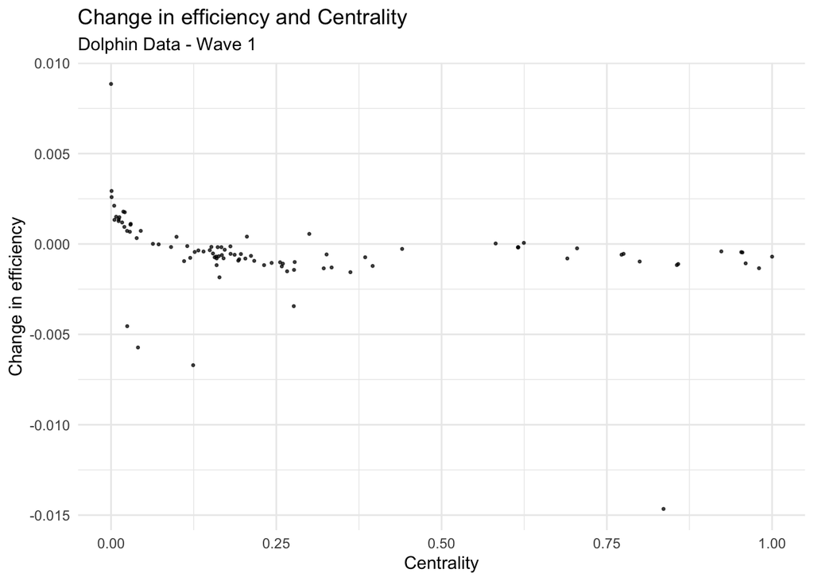

```r
removal_w1_first %>%
  mutate(centrality = as.numeric(centrality),
         change_efficiency = as.numeric(change_efficiency)) %>%
  ggplot(aes(x= centrality, y = change_efficiency)) +
  geom_point(alpha = 0.7, size = 0.5) +
  theme_minimal() +
  labs(title = "Change in efficiency and Centrality",
       subtitle = "Dolphin Data - Wave 1",
       y = "Change in efficiency",
       x = "Centrality")
```

We notice a rather interesting pattern. Most node removals have roughly the same effect, regardless of their centrality. Except one that has an disproportionate effect when removed.

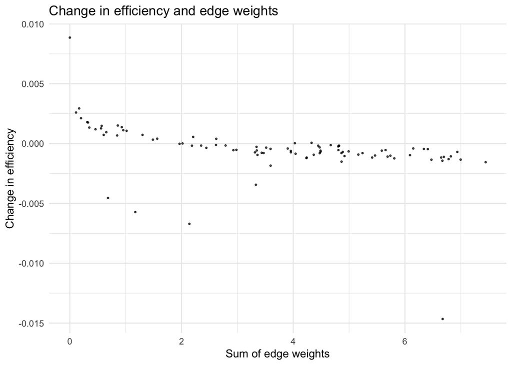

```r
removal_w1_first %>%
  mutate(sum_edge_weights = as.numeric(sum_edge_weights),
         change_efficiency = as.numeric(change_efficiency)) %>%
  ggplot(aes(x= sum_edge_weights, y = change_efficiency)) +
  geom_point(alpha = 0.7, size = 0.5) +
  theme_minimal() +
  labs(title = "Change in efficiency and edge weights",
       y = "Change in efficiency",
       x = "Sum of edge weights")
```

We notice the same pattern when we look at the sum of edge weights.

Let’s remove that node and then see what the other best one would be.

```r
g_after_first <- delete.vertices(dolphin_w1, V(dolphin_w1)[1])

removal_w1_second <- decrease_efficiency(g_after_first)

which.max(removal_w1_second$change_efficiency)
```

```
## [1] 42
```

```r
g_after_second <- delete.vertices(g_after_first, V(g_after_first)[35])
removal_w1_third <- decrease_efficiency(g_after_second)
which.max(removal_w1_third$change_efficiency)
```

```
## [1] 23
```

```r
g_after_third <- delete.vertices(g_after_second, V(g_after_second)[1])
removal_w1_fourth <- decrease_efficiency(g_after_third)
which.max(removal_w1_fourth$change_efficiency)
```

```
## [1] 22
```

```r
g_after_fourth <- delete.vertices(g_after_third, V(g_after_third)[30])
removal_w1_fifth <- decrease_efficiency(g_after_fourth)
which.max(removal_w1_fifth$change_efficiency)
```

```
## [1] 22
```

```r
g_all_removals <- delete.vertices(g_after_fourth, V(g_after_fourth)[62])
```

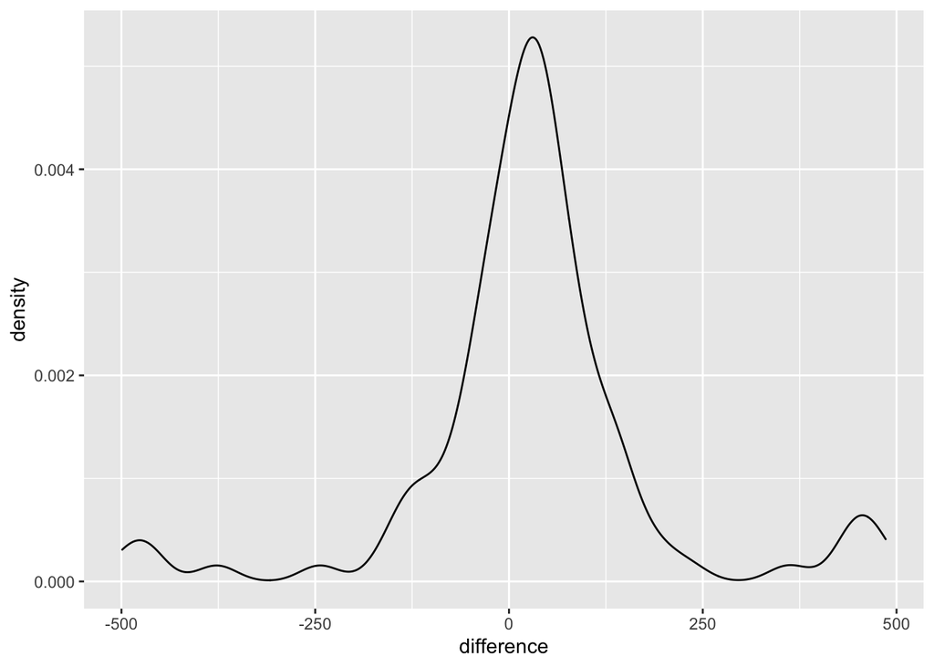

```r
set.seed(76)
turn_reached_max_decrease <- function(ev, g, g2, reps, turns) {
  # Place holder
  values <- rep(NA, reps)

  for (i in 1:reps) {
    sim <- info_contagion(g,
                          rewire = F,
                          e = ev,
                          r_max = turns)
    ttm <- sim$time_to_max[1]

    # Now some centrality removal
    sim_r <- info_contagion(g2,
                            rewire = F,
                            e = ev,
                            r_max = turns)
    ttmr <- sim_r$time_to_max[1]

    values[i] <- ttm-ttmr
  }
  return(values)
}

diff_max_decrease_w1 <- turn_reached_max_decrease(ev =1,
                          g = dolphin_w1,
                          g2 = g_all_removals,
                          reps = 100,
                          turns = 500)
tibble(run = 1:100,
       difference = diff_max_decrease_w1) %>%
  ggplot(aes(x = difference)) +
  geom_density(alpha = 0.3)
```

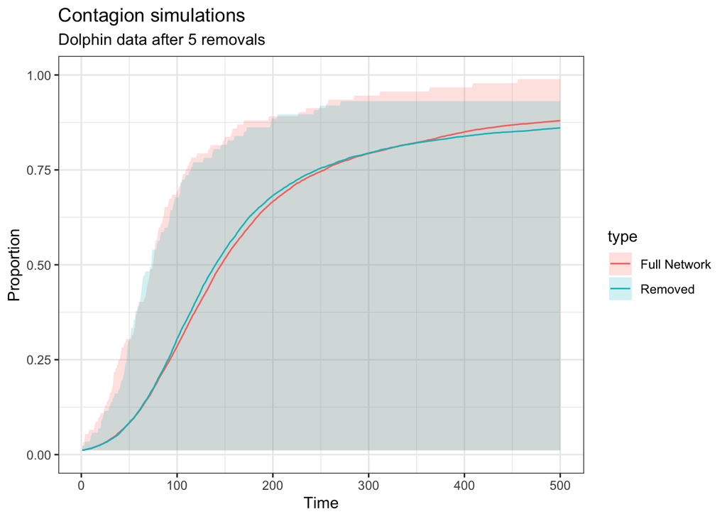

```r
no_removals_contagion <- map_df(c(1:100),
       info_contagion,
       net = dolphin_w1,
       rewire = F,
       r_max = 500,
       e =1 )
removals_contagion <- map_df(c(1:100),
       info_contagion,
       net = g_all_removals,
       rewire = F,
       r_max = 500,
       e =1 )

summary_nr <- no_removals_contagion %>%
  group_by(time) %>%
  summarise(avg = mean(proportion),
            upper = max(proportion),
            lower = min(proportion)) %>%
  mutate(type = "Full Network")
summary_rem <- removals_contagion %>%
  group_by(time) %>%
  summarise(avg = mean(proportion),
            upper = max(proportion),
            lower = min(proportion)) %>%
  mutate(type = "Removed")
complete_contagion <- rbind(summary_nr,
                            summary_rem)

complete_contagion %>%
  ggplot(aes(x = time, y = avg, fill = type)) +
  geom_ribbon(aes(ymin = lower, ymax = upper, fill= type), alpha = 0.2) +
  geom_line(size = 0.5, aes(color = type)) +
  labs(x = "Time",
       y = "Proportion",
       title = "Contagion simulations",
       subtitle = "Dolphin data after 5 removals") +
   ylim(c(0,1)) +
  theme_bw()
```

The structure after these targeted removals is not as efficient in transmitting culture across all its nodes, especially towards the later time-steps of the simulation. We got this after 5 removals, which I think is consequential given how robust these structures are to node removal in general.